# Live MMR progress: Grubby’s Invitational participants

This page tracks and archives W3C gameplay stats for all participants of Grubby’s invitational tournaments. To date, this includes *Onlyfangs*, *Streamer* and *Altar of Champions* invitationals.

Interactive charts allow to zoom/pan to timeframes of interest, and toggle view of specific players for comparison.

Select your tab:

**Rating progress & timelines:**

Current Season & Leaderboard

*Altar of Champions* (2026) players, main race only

All participants, invitationals, races (2025-2026)

Coaches/notable streamers

**Tournament Archive:**

*Altar of Champions (May 2026)*

Recap: stats and moments  
Snapshot: MMR timeline  
Snapshot: MMR progress (game history)  
Snapshot: game volume, win, loss, streak and match-up winrates

*Streamer Invitational (April 2025)*  
*OnlyFangs Invitational (March 2025)*

2025 recap

**Credits & About**

Author: [SinXL](https://sinxl-wc3.github.io/)

Data: [W3Champions](https://w3champions.com/), [Liquipedia](https://liquipedia.net/warcraft/Main_Page)

# **Current Season & Leaderboard**

### **Leaderboard: Current MMR**

Records with <10 games per player/race excluded from visualization/listing.

| MMR | Player | Race | Games |
| --- | --- | --- | --- |
| 1469 | Hera | UD | 457 |
| 1425 | YamatoCannon | HU | 336 |
| 1420 | RedPanda | ORC | 12 |
| 1353 | Tyler1 | ORC | 273 |
| 1309 | Pohx | NE | 116 |
| 1288 | Simply | NE | 266 |
| 1259 | Ahmpy | NE | 273 |
| 1192 | Ahmpy | ORC | 110 |
| 1168 | RedPanda | NE | 133 |
| 1166 | Maxim | HU | 74 |
| 863 | Simply | ORC | 30 |
| 847 | Ahmpy | UD | 36 |
| 723 | Ahmpy | HU | 18 |
| 566 | Dantes | UD | 93 |
| 409 | MaryMaybe | ORC | 48 |

### S24 all people

[interactive chart not shown]

# **MMR Timeline** *(Altar of Champions)*

[interactive chart not shown]

# **All Participants** *(all Invitationals/Players/Races)*

[interactive chart not shown]

# **Coaches/notable streamers** *(Non-contestants)*

### **Leaderboard: Current MMR**

Records with <10 games per player/race excluded from visualization/listing.

| MMR | Player | Race | Games |
| --- | --- | --- | --- |
| 2783 | Jens 2 | NE | 62 |
| 2758 | StarBuck 2 | ORC | 146 |
| 2716 | StarBuck 2 | HU | 75 |
| 2708 | StarBuck 1 | HU | 79 |
| 2682 | StarBuck 1 | ORC | 55 |
| 2670 | XlorD | UD | 15 |
| 2664 | Jens 1 | NE | 387 |
| 2636 | Hitman | ORC | 2091 |
| 2601 | StarBuck 2 | Random | 77 |
| 2569 | Sonik | NE | 525 |
| 2564 | Deathnote | HU | 711 |
| 2550 | PaTo | NE | 282 |
| 2550 | StarBuck 1 | NE | 24 |
| 2536 | StarBuck 2 | NE | 28 |
| 2529 | Foggy | NE | 50 |
| 2511 | SoYma | NE | 499 |
| 2501 | Kevin | NE | 265 |
| 2501 | Leon | HU | 417 |
| 2498 | Grubby | ORC | 71 |
| 2497 | StarBuck 1 | Random | 59 |
| 2487 | XlorD | Random | 275 |
| 2486 | Jens 2 | Random | 63 |
| 2425 | Ladziuk | ORC | 997 |
| 2416 | sheik | UD | 259 |
| 2386 | SaySo | UD | 266 |
| 2376 | SaySo | Random | 83 |
| 2370 | XlorD | NE | 99 |
| 2345 | Smurf | NE | 666 |
| 2338 | Knoff | ORC | 60 |
| 2328 | sheik | ORC | 192 |
| 2325 | Grubby | UD | 62 |
| 2295 | Jens 1 | Random | 104 |
| 2283 | sheik | HU | 56 |
| 2250 | KroLu | ORC | 600 |
| 2238 | SaySo | ORC | 43 |
| 2230 | Grubby | HU | 14 |
| 2227 | Grubby | NE | 22 |
| 2220 | PaTo | HU | 24 |
| 2210 | KroLu | HU | 325 |
| 2210 | Ladziuk | Random | 54 |
| 2207 | sheik | NE | 49 |
| 2196 | SaySo | NE | 29 |
| 2175 | Foggy | Random | 18 |
| 2167 | SoYma | ORC | 90 |
| 2155 | Ladziuk | UD | 31 |
| 2142 | OsgPACMAN | HU | 1928 |
| 2121 | Smurf | ORC | 105 |
| 2116 | Rollex | HU | 1345 |
| 2103 | Kevin | ORC | 43 |
| 2100 | Ladziuk | HU | 55 |
| 2080 | StiCkla | NE | 268 |
| 2063 | carsoNNN | ORC | 686 |
| 2027 | Smurf | UD | 21 |
| 2023 | Smurf | HU | 29 |
| 1985 | SaulApeMan | UD | 17 |
| 1978 | Ladziuk | NE | 29 |
| 1977 | Leon | UD | 65 |
| 1945 | SaulApeMan | NE | 45 |
| 1898 | SaulApeMan | Random | 68 |
| 1877 | SaulApeMan | HU | 39 |
| 1820 | SaulApeMan | ORC | 49 |
| 1817 | remodemo | ORC | 78 |
| 1680 | Rollex | Random | 25 |
| 1590 | StiCkla | ORC | 27 |
| 1428 | Atrioc | NE | 363 |
| 1414 | Neo | UD | 289 |
| 777 | Angelikatosh | ORC | 28 |

### S24 others

[interactive chart not shown]

### Chart MMR-by-GameNo

[interactive chart not shown]

### **Game data**

[interactive chart not shown]

### **Top 10 longest streaks**

| Player | Streak |
| --- | --- |
| Tyler1 | 15 losses in a row |
| Hera | 14 wins in a row |
| Pohx | 13 wins in a row |
| Tyler1 | 12 losses in a row |
| Hera | 11 wins in a row |
| Tyler1 | 11 wins in a row |
| YamatoCannon | 11 wins in a row |
| Hera | 10 wins in a row |
| Hera | 10 wins in a row |
| YamatoCannon | 10 wins in a row |

### **Longest win and loss streaks per player**

| Player | Longest Win Streak | Longest Loss Streak |
| --- | --- | --- |
| Dantes | 6 | 9 |
| Hera | 14 | 7 |
| MaryMaybe | 5 | 4 |
| Maxim | 9 | 4 |
| Pohx | 13 | 5 |
| Simply | 9 | 6 |
| Tyler1 | 11 | 15 |
| YamatoCannon | 11 | 5 |

### Match-up winrates

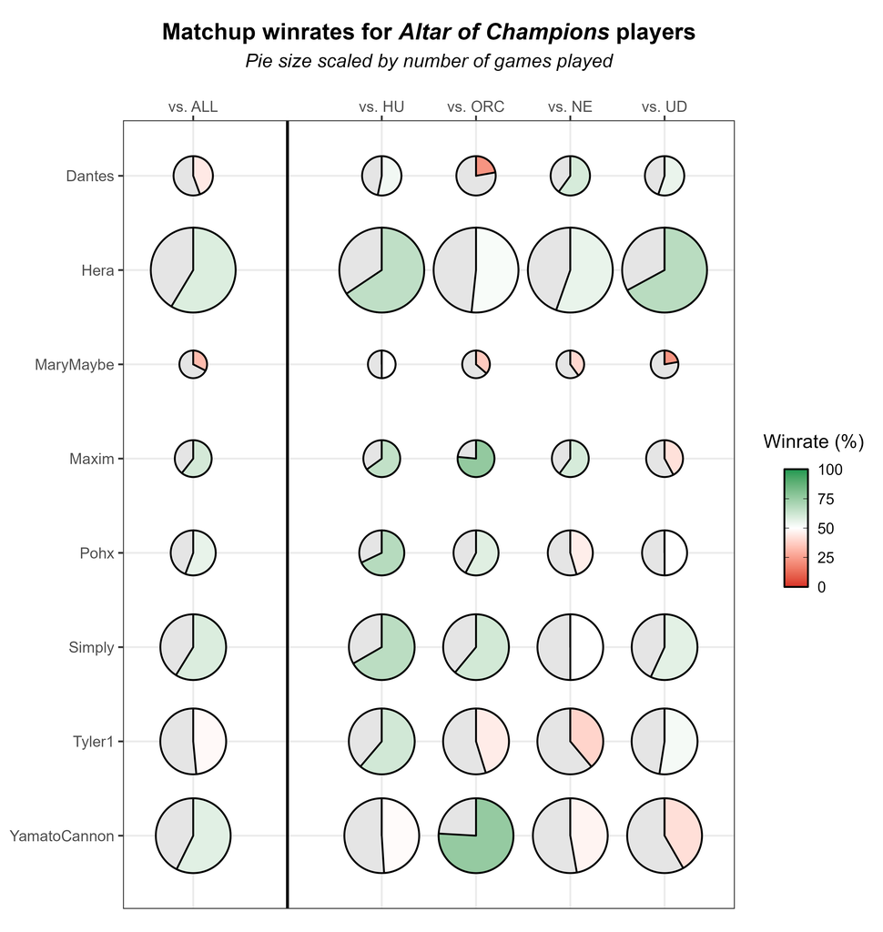

### **Altar of Champions (2026)**

[Tournament announcement page](https://grubby-poc.azurewebsites.net/AltarOfChampions) and brackets: [Clan War](https://liquipedia.net/warcraft/Altar_of_Champions/Clan_War) / 1v1

Players: **Dantes** (UD), **Hera** (UD), **MaryMaybe** (ORC), **Maxim** (HU), **Pohx** (NE), **Simply** (NE), **Tyler1** (ORC), **YamatoCannon** (HU)

Data archive: MMR timelines, progress through game history and ladder game stats for *Altar of Champions* players over their training arcs

Memorable moments:

- Tournament split in two, opening with a Clan War format, involving a riveting BO5 going full distance with **Hera** beating **YamatoCannon** by a single map margin (foreshadowing a similar grand final two days later).
- Grand final reverse sweep by **Hera**, coming in from lower bracket needing to play two BO5s back-to-back and with significant map pick disadvantage against **YamatoCannon**.
- Heavy coach involvement with all participants (**Deathnote**, **SaySo**, **SaulApeMan**, **Sythren**, **Kevin**, **Smurf**, **Leon**, **Hailua**, **ToD**, **Knoff**, **Grubby**).
- **Simply** turning two games in a row with last second Demon Hunter metamorphosis plays against **Hera** in upper bracket semifinals.
- Many unique moments: **MaryMaybe** proxy great hall expansion at goblin lab, **Dantes** struggling with building a graveyard; **MaryMaybe** jumping the gun but not closing out a successful T2-timing tower rush vs. **Dantes**; **YamatoCannon** recieving coaching from **Deathnote**; **Pohx** taking a map off **YamatoCannon** in a chaotic siege engine game with his signature Warden opening.
- **Pohx** beating **Hera** a day prior to tournament, causing major drop in MMR and mindset for eventual tournament champion.
- Though their game record in the tournament was 2-1 and 2-0, **Tyler1** often outplayed and almost closed out several games vs. **Hera**.

Notable stats:

- Median MMR ahead of tournament day was 1200. This threshold was stably cleared quickest in the following number of games: **Pohx** (76), **Tyler1** (80), **YamatoCannon** (96), and **Hera** (261). **Simply** also crossed 1200 twice, though unstably.
- Longest win streak held by **Hera** (14), surpassing **Pohx** (13) on final day.
- 10+ win streaks held by **Hera** (14, 11, 10, 10), **YamatoCannon** (11, 10), **Pohx** (13) and **Tyler1** (11).
- Two longest loss streaks held by **Tyler1** (15, 12).
- Most extreme match-up specialists were the two HU players: **YamatoCannon** (75.9% winrate vs. ORC) and **Maxim** (76.5% winrate vs. ORC).

### **OnlyFangs Invitational (March 2025)**

Tournament info: [Liquipedia](https://liquipedia.net/warcraft/OnlyFangs_Invitational)

Players: **Ahmpy** (NE), **AnnieFuchsia** (HU), **Dendi** (HU), **Guzu** (HU), **LoLGeranimo** (NE), **sodapoppin** (UD), **sunglitters** (HU), **Tyler1** (ORC)

### **Streamer Invitational (April 2025)**

Tournament info: [Liquipedia](https://liquipedia.net/warcraft/Warcraft_3_Streamer_Invitational)

Players: **Lacari** (NE), **Lowko** (NE), **RedPanda** (ORC), **SingSing** (HU), **Tasteless** (UD), **TheViper** (ORC), **TommyKay** (HU), **Turin** (UD)

### 2025 summary picture

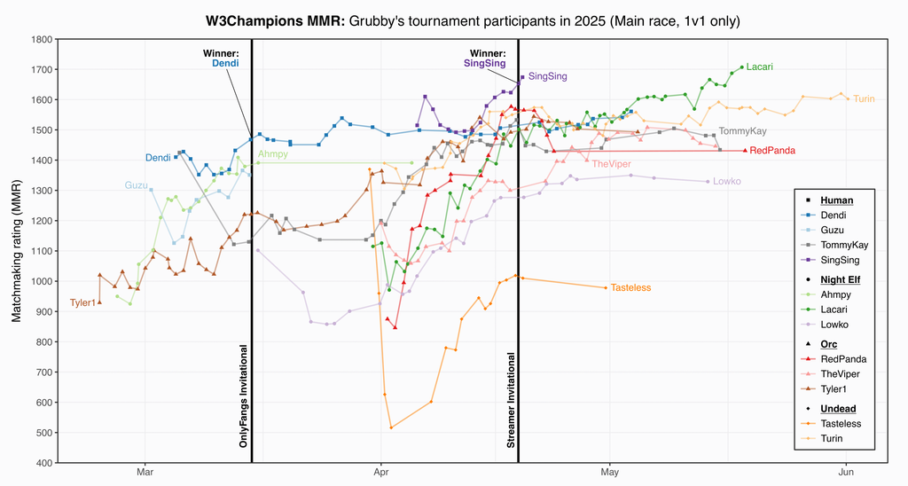